# Insurance Claim Prediction Classification Trees

Lance Dugger

## Problem Description

The insurance training data set is a csv file consisting of 25 columns that describe different customer attributes for an insurance company. The target column includes whether these customers filed a claim or not. Classification tree methods will be used to develop a model that will predict whether a customer will file a claim or not.

## Data Exploration

```r
# Data Import and Variable Type Changes
data <- read.csv("logit_insurance.csv")

### Need to make sure our data is understood correctly by R, since we have a mix of numerical and categorical
data$INDEX <- as.factor(data$INDEX)
data$TARGET_FLAG <- as.factor(data$TARGET_FLAG)
data$SEX <- as.factor(data$SEX)
data$EDUCATION <- as.factor(data$EDUCATION)
data$PARENT1 <- as.factor(data$PARENT1)
data$INCOME <- suppressWarnings(as.numeric(gsub("[^0-9.]", "", data$INCOME)))

data$HOME_VAL <- suppressWarnings(as.numeric(gsub("[^0-9.]", "", data$HOME_VAL)))
data$MSTATUS <- as.factor(data$MSTATUS)
data$REVOKED <- as.factor(data$REVOKED)
data$RED_CAR <- as.factor(ifelse(data$RED_CAR=="yes", 1, 0))
data$URBANICITY <- ifelse(data$URBANICITY == "Highly Urban/ Urban", "Urban", "Rural")
data$URBANICITY <- as.factor(data$URBANICITY)
data$JOB <- as.factor(data$JOB)
data$CAR_USE <- as.factor(data$CAR_USE)
data$CAR_TYPE <- as.factor(data$CAR_TYPE)
data$DO_KIDS_DRIVE <- as.factor(ifelse(data$KIDSDRIV > 0, 1, 0 ))
data$OLDCLAIM <- suppressWarnings(as.numeric(gsub("[^0-9.]", "", data$HOME_VAL)))
data$BLUEBOOK <- suppressWarnings(as.numeric(gsub("[^0-9.]", "", data$BLUEBOOK)))
summary(data)
```

```
##      INDEX      TARGET_FLAG   TARGET_AMT        KIDSDRIV           AGE
##  1      :   1   0:6008      Min.   :     0   Min.   :0.0000   Min.   :16.00
##  2      :   1   1:2153      1st Qu.:     0   1st Qu.:0.0000   1st Qu.:39.00
##  4      :   1               Median :     0   Median :0.0000   Median :45.00
##  5      :   1               Mean   :  1504   Mean   :0.1711   Mean   :44.79
##  6      :   1               3rd Qu.:  1036   3rd Qu.:0.0000   3rd Qu.:51.00
##  7      :   1               Max.   :107586   Max.   :4.0000   Max.   :81.00
##  (Other):8155                                                 NA's   :6
##     HOMEKIDS           YOJ           INCOME       PARENT1       HOME_VAL
##  Min.   :0.0000   Min.   : 0.0   Min.   :     0   No :7084   Min.   :     0
##  1st Qu.:0.0000   1st Qu.: 9.0   1st Qu.: 28097   Yes:1077   1st Qu.:     0
##  Median :0.0000   Median :11.0   Median : 54028              Median :161160
##  Mean   :0.7212   Mean   :10.5   Mean   : 61898              Mean   :154867
##  3rd Qu.:1.0000   3rd Qu.:13.0   3rd Qu.: 85986              3rd Qu.:238724
##  Max.   :5.0000   Max.   :23.0   Max.   :367030              Max.   :885282
##                   NA's   :454    NA's   :445                 NA's   :464
##  MSTATUS      SEX               EDUCATION               JOB
##  Yes :4894   M  :3786   <High School :1203   z_Blue Collar:1825
##  z_No:3267   z_F:4375   Bachelors    :2242   Clerical     :1271
##                         Masters      :1658   Professional :1117
##                         PhD          : 728   Manager      : 988
##                         z_High School:2330   Lawyer       : 835
##                                              Student      : 712
##                                              (Other)      :1413
##     TRAVTIME            CAR_USE        BLUEBOOK          TIF
##  Min.   :  5.00   Commercial:3029   Min.   : 1500   Min.   : 1.000
##  1st Qu.: 22.00   Private   :5132   1st Qu.: 9280   1st Qu.: 1.000
##  Median : 33.00                     Median :14440   Median : 4.000
##  Mean   : 33.49                     Mean   :15710   Mean   : 5.351
##  3rd Qu.: 44.00                     3rd Qu.:20850   3rd Qu.: 7.000
##  Max.   :142.00                     Max.   :69740   Max.   :25.000
##
##         CAR_TYPE    RED_CAR     OLDCLAIM         CLM_FREQ      REVOKED
##  Minivan    :2145   0:5783   Min.   :     0   Min.   :0.0000   No :7161
##  Panel Truck: 676   1:2378   1st Qu.:     0   1st Qu.:0.0000   Yes:1000
##  Pickup     :1389            Median :161160   Median :0.0000
##  Sports Car : 907            Mean   :154867   Mean   :0.7986
##  Van        : 750            3rd Qu.:238724   3rd Qu.:2.0000
##  z_SUV      :2294            Max.   :885282   Max.   :5.0000
##                              NA's   :464
##     MVR_PTS          CAR_AGE       URBANICITY   DO_KIDS_DRIVE
##  Min.   : 0.000   Min.   :-3.000   Rural:1669   0:7180
##  1st Qu.: 0.000   1st Qu.: 1.000   Urban:6492   1: 981
##  Median : 1.000   Median : 8.000
##  Mean   : 1.696   Mean   : 8.328
##  3rd Qu.: 3.000   3rd Qu.:12.000
##  Max.   :13.000   Max.   :28.000
##                   NA's   :510
```

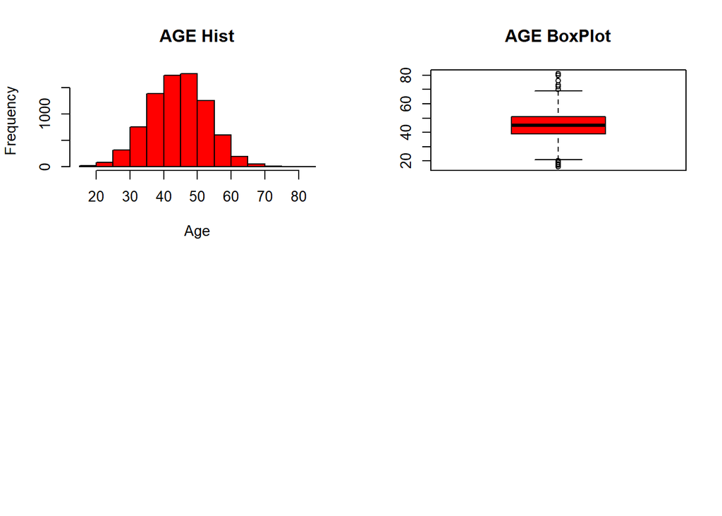

```r
# Histograms for Numeric Variables
par(mfrow=c(2,2))
hist(data$AGE, col = "red", xlab = "Age", main = "AGE Hist")
data0<- subset(data, TARGET_FLAG == 1 )
boxplot(data$AGE, col = "red", main = "AGE BoxPlot")
par(mfrow=c(1,1))
```

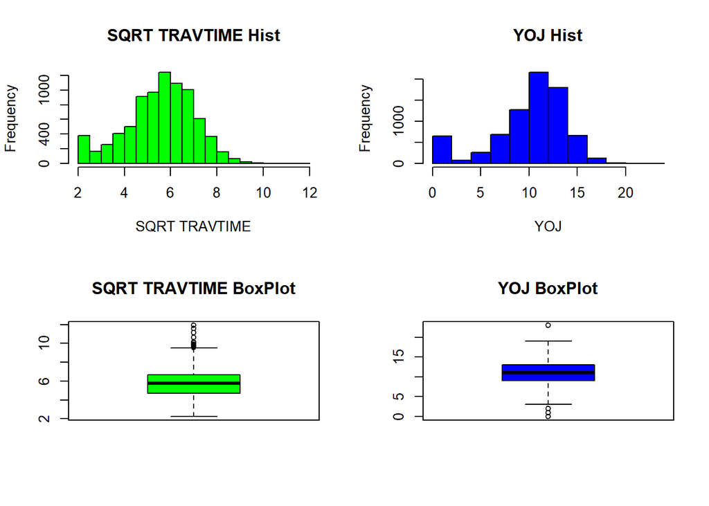

```r
par(mfrow=c(2,2))
hist(sqrt(data$TRAVTIME), col = "green", xlab = "SQRT TRAVTIME", main = "SQRT TRAVTIME Hist")
hist(data$YOJ, col = "blue", xlab = "YOJ", main = "YOJ Hist")
boxplot(sqrt(data$TRAVTIME), col = "green", main = "SQRT TRAVTIME BoxPlot")
boxplot(data$YOJ, col = "blue", main = "YOJ BoxPlot")
```

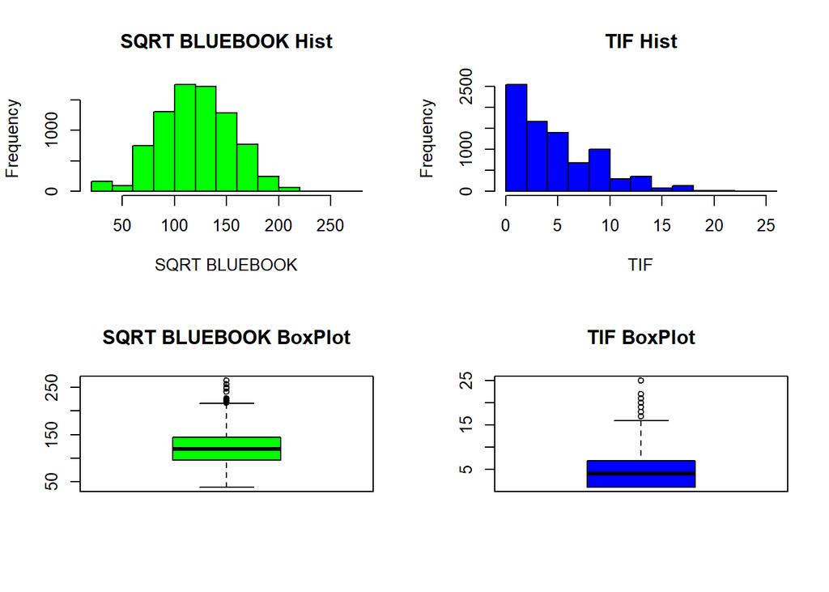

```r
par(mfrow=c(1,1))

par(mfrow=c(2,2))
hist(sqrt(data$BLUEBOOK), col = "green", xlab = "SQRT BLUEBOOK", main = "SQRT BLUEBOOK Hist")
hist((data$TIF), col = "blue", xlab = "TIF", main = "TIF Hist")
boxplot(sqrt(data$BLUEBOOK), col = "green", main = "SQRT BLUEBOOK BoxPlot")
boxplot(data$TIF, col = "blue", main = "TIF BoxPlot")
```

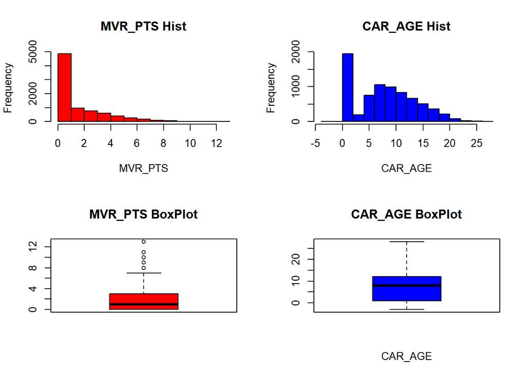

```r
par(mfrow=c(1,1))

par(mfrow=c(2,2))
hist(data$MVR_PTS, col = "red", xlab = "MVR_PTS", main = "MVR_PTS Hist")
hist(data$CAR_AGE, col = "blue", xlab = "CAR_AGE", main = "CAR_AGE Hist")
boxplot(data$MVR_PTS, col = "red", main = "MVR_PTS BoxPlot")
boxplot(data$CAR_AGE, col = "blue", xlab = "CAR_AGE", main = "CAR_AGE BoxPlot")
```

```r
par(mfrow=c(1,1))
```

## Data Preparation

```r
# Fix NA's, code necessary variables
data$AGE[is.na(data$AGE)] <- mean(data$AGE, na.rm = "TRUE")
data$YOJ <- na.aggregate(data$YOJ, data$JOB, mean, na.rm = TRUE)
data$INCOME <- na.aggregate(data$INCOME, data$JOB, mean, na.rm = TRUE)
data$HOME_VAL <- na.aggregate(data$HOME_VAL, data$JOB, mean, na.rm = TRUE )
data$CAR_AGE <- na.aggregate(data$CAR_AGE, data$CAR_TYPE, mean, na.rm = TRUE)
data$CAR_AGE[data$CAR_AGE < 0 ] <- 0
data$OLDCLAIM <- ifelse(data$CAR_AGE < 5 & !is.na(data$CAR_AGE),0,data$OLDCLAIM)
data$OLDCLAIM <- na.aggregate(data$OLDCLAIM, data$CAR_AGE, mean, na.rm = TRUE )
data$HOME_OWNER <- ifelse(data$HOME_VAL == 0, 0, 1)
data$YOUNG <- ifelse(data$AGE < 29, 1, 0)
data$HAS_KIDS <- ifelse(data$HOMEKIDS == 0, 0, 1)
data$OLD_CAR <- ifelse(data$CAR_AGE > 20, 1, 0)
data$COLLEGE <- ifelse(data$EDUCATION == "Bachelors" |data$EDUCATION == "Masters" | data$EDUCATION == "PhD", 1, 0)
data$NEW_JOB <- ifelse(data$YOJ < 8, 1, 0)
data$MANAGER <- ifelse(data$JOB == "Manager", 1, 0)
data$CHEAP_CAR <- ifelse(data$BLUEBOOK < 6000, 1, 0)

# Bin Income
data$INCOME_bin[is.na(data$INCOME)] <- "NA"
data$INCOME_bin[data$INCOME == 0] <- "Zero"
data$INCOME_bin[data$INCOME >= 1 & data$INCOME < 30000] <- "Low"
data$INCOME_bin[data$INCOME >= 30000 & data$INCOME < 80000] <- "Medium"
data$INCOME_bin[data$INCOME >= 80000] <- "High"
data$INCOME_bin <- factor(data$INCOME_bin)
data$INCOME_bin <- factor(data$INCOME_bin, levels=c("NA","Zero","Low","Medium","High"))

summary(data)
```

```
##      INDEX      TARGET_FLAG   TARGET_AMT        KIDSDRIV           AGE
##  1      :   1   0:6008      Min.   :     0   Min.   :0.0000   Min.   :16.00
##  2      :   1   1:2153      1st Qu.:     0   1st Qu.:0.0000   1st Qu.:39.00
##  4      :   1               Median :     0   Median :0.0000   Median :45.00
##  5      :   1               Mean   :  1504   Mean   :0.1711   Mean   :44.79
##  6      :   1               3rd Qu.:  1036   3rd Qu.:0.0000   3rd Qu.:51.00
##  7      :   1               Max.   :107586   Max.   :4.0000   Max.   :81.00
##  (Other):8155
##     HOMEKIDS           YOJ            INCOME       PARENT1       HOME_VAL
##  Min.   :0.0000   Min.   : 0.00   Min.   :     0   No :7084   Min.   :     0
##  1st Qu.:0.0000   1st Qu.: 9.00   1st Qu.: 28299   Yes:1077   1st Qu.:     0
##  Median :0.0000   Median :11.34   Median : 54877              Median :160429
##  Mean   :0.7212   Mean   :10.50   Mean   : 61603              Mean   :154848
##  3rd Qu.:1.0000   3rd Qu.:13.00   3rd Qu.: 86268              3rd Qu.:234300
##  Max.   :5.0000   Max.   :23.00   Max.   :367030              Max.   :885282
##
##  MSTATUS      SEX               EDUCATION               JOB
##  Yes :4894   M  :3786   <High School :1203   z_Blue Collar:1825
##  z_No:3267   z_F:4375   Bachelors    :2242   Clerical     :1271
##                         Masters      :1658   Professional :1117
##                         PhD          : 728   Manager      : 988
##                         z_High School:2330   Lawyer       : 835
##                                              Student      : 712
##                                              (Other)      :1413
##     TRAVTIME            CAR_USE        BLUEBOOK          TIF
##  Min.   :  5.00   Commercial:3029   Min.   : 1500   Min.   : 1.000
##  1st Qu.: 22.00   Private   :5132   1st Qu.: 9280   1st Qu.: 1.000
##  Median : 33.00                     Median :14440   Median : 4.000
##  Mean   : 33.49                     Mean   :15710   Mean   : 5.351
##  3rd Qu.: 44.00                     3rd Qu.:20850   3rd Qu.: 7.000
##  Max.   :142.00                     Max.   :69740   Max.   :25.000
##
##         CAR_TYPE    RED_CAR     OLDCLAIM         CLM_FREQ      REVOKED
##  Minivan    :2145   0:5783   Min.   :     0   Min.   :0.0000   No :7161
##  Panel Truck: 676   1:2378   1st Qu.:     0   1st Qu.:0.0000   Yes:1000
##  Pickup     :1389            Median :105347   Median :0.0000
##  Sports Car : 907            Mean   :122099   Mean   :0.7986
##  Van        : 750            3rd Qu.:218964   3rd Qu.:2.0000
##  z_SUV      :2294            Max.   :885282   Max.   :5.0000
##
```

[output cut: 9 more lines]

```
##  Min.   :0.00000   Min.   :0.0000   Min.   :0.00000   Min.   :0.0000
##  1st Qu.:0.00000   1st Qu.:0.0000   1st Qu.:0.00000   1st Qu.:0.0000
##  Median :0.00000   Median :0.0000   Median :0.00000   Median :1.0000
##  Mean   :0.03088   Mean   :0.3519   Mean   :0.01421   Mean   :0.5671
##  3rd Qu.:0.00000   3rd Qu.:1.0000   3rd Qu.:0.00000   3rd Qu.:1.0000
##  Max.   :1.00000   Max.   :1.0000   Max.   :1.00000   Max.   :1.0000
##
##     NEW_JOB          MANAGER         CHEAP_CAR        INCOME_bin
##  Min.   :0.0000   Min.   :0.0000   Min.   :0.00000   NA    :   0
##  1st Qu.:0.0000   1st Qu.:0.0000   1st Qu.:0.00000   Zero  : 615
##  Median :0.0000   Median :0.0000   Median :0.00000   Low   :1540
##  Mean   :0.1669   Mean   :0.1211   Mean   :0.09705   Medium:3693
##  3rd Qu.:0.0000   3rd Qu.:0.0000   3rd Qu.:0.00000   High  :2313
##  Max.   :1.0000   Max.   :1.0000   Max.   :1.00000
##
```

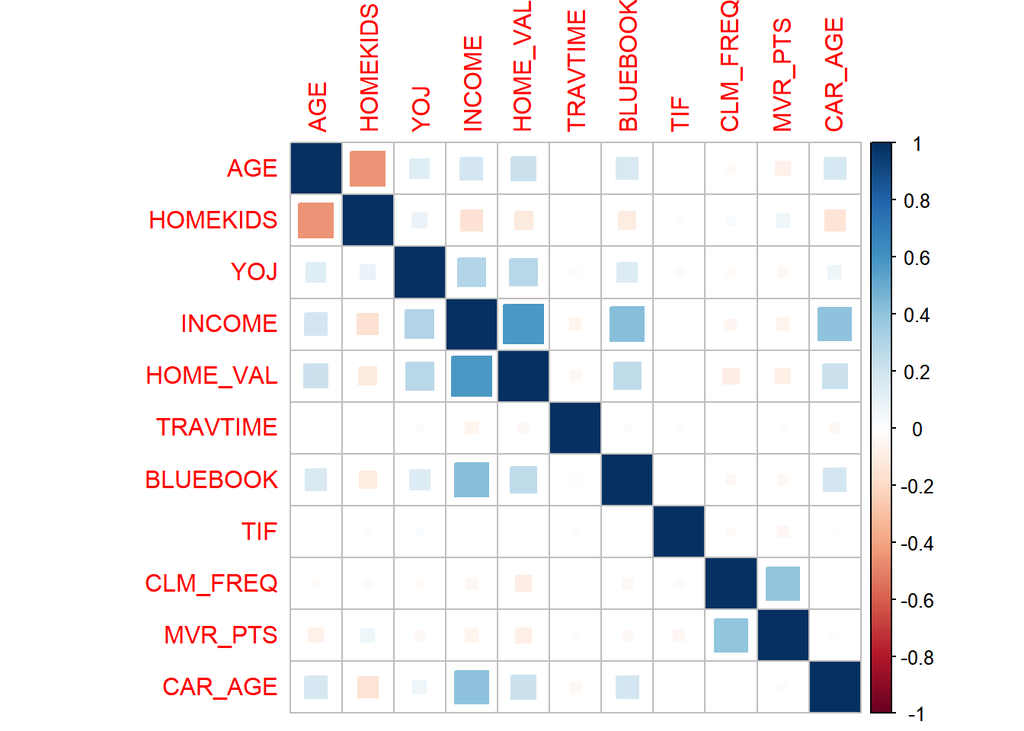

```r
numeric <- subset(data, select = c(AGE, HOMEKIDS, YOJ, INCOME, HOME_VAL, TRAVTIME, BLUEBOOK, TIF,
                                   CLM_FREQ, MVR_PTS, CAR_AGE), na.rm = TRUE)
c <- cor(numeric)
corrplot(c, method = "square")
```

## Model Creation

```r
#Set training and test sets
set.seed(1)
train.set <- sample(1:nrow(data), as.integer(nrow(data) * 0.8))
test.set <- (-train.set)

#Classification Tree w/pruning
Model1 <- tree(TARGET_FLAG ~ YOUNG + CHEAP_CAR + TRAVTIME + KIDSDRIV + URBANICITY + HAS_KIDS +
                  CLM_FREQ + REVOKED + MVR_PTS + OLD_CAR + TIF + COLLEGE + MSTATUS + PARENT1 +
                  CAR_USE + CAR_TYPE + NEW_JOB + MANAGER + INCOME_bin + HOME_OWNER,
                data = data[train.set,])
Model1.pred <- predict(Model1, data[test.set,], type = "class")

summary(Model1)
```

```
##
## Classification tree:
## tree(formula = TARGET_FLAG ~ YOUNG + CHEAP_CAR + TRAVTIME + KIDSDRIV +
##     URBANICITY + HAS_KIDS + CLM_FREQ + REVOKED + MVR_PTS + OLD_CAR +
##     TIF + COLLEGE + MSTATUS + PARENT1 + CAR_USE + CAR_TYPE +
##     NEW_JOB + MANAGER + INCOME_bin + HOME_OWNER, data = data[train.set,
##     ])
## Variables actually used in tree construction:
## [1] "URBANICITY" "COLLEGE"    "CLM_FREQ"   "PARENT1"
## Number of terminal nodes:  5
## Residual mean deviance:  1.026 = 6690 / 6523
## Misclassification error rate: 0.2646 = 1727 / 6528
```

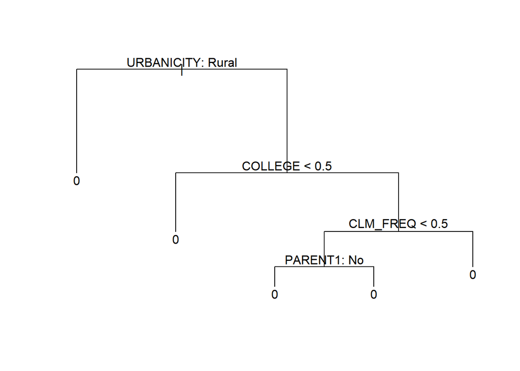

```r
plot(Model1)
text(Model1, pretty = 0)
```

```r
Model1
```

```
## node), split, n, deviance, yval, (yprob)
##       * denotes terminal node
##
##  1) root 6528 7543.0 0 ( 0.73545 0.26455 )
##    2) URBANICITY: Rural 1333  664.2 0 ( 0.93173 0.06827 ) *
##    3) URBANICITY: Urban 5195 6473.0 0 ( 0.68508 0.31492 )
##      6) COLLEGE < 0.5 1971 2705.0 0 ( 0.55911 0.44089 ) *
##      7) COLLEGE > 0.5 3224 3538.0 0 ( 0.76210 0.23790 )
##       14) CLM_FREQ < 0.5 1862 1651.0 0 ( 0.83781 0.16219 )
##         28) PARENT1: No 1678 1323.0 0 ( 0.86591 0.13409 ) *
##         29) PARENT1: Yes 184  250.2 0 ( 0.58152 0.41848 ) *
##       15) CLM_FREQ > 0.5 1362 1749.0 0 ( 0.65859 0.34141 ) *
```

```r
Model1.table <- table(Model1.pred, data$TARGET_FLAG[test.set])
Model1.table
```

```
##
## Model1.pred    0    1
##           0 1207  426
##           1    0    0
```

```r
#Overall Accuracy
(Model1.table[1] + Model1.table[4])/sum(Model1.table)
```

```
## [1] 0.7391304
```

```r
#Claim Accuracy
Model1.table[4]/(Model1.table[3] + Model1.table[4])
```

```
## [1] 0
```

```r
#No Claim Accuracy
Model1.table[1]/(Model1.table[1] + Model1.table[2])
```

```
## [1] 1
```

```r
#Prune
set.seed(2)
Model1.cv <- cv.tree(Model1, FUN = prune.misclass)
Model1.cv
```

```
## $size
## [1] 5 1
##
## $dev
## [1] 1704 1704
##
## $k
## [1] -Inf    0
##
## $method
## [1] "misclass"
##
## attr(,"class")
## [1] "prune"         "tree.sequence"
```

```r
#Bagging
set.seed(3)
Model2 <- randomForest(TARGET_FLAG ~ YOUNG + CHEAP_CAR + TRAVTIME + KIDSDRIV + URBANICITY + HAS_KIDS +
                           CLM_FREQ + REVOKED + MVR_PTS + OLD_CAR + TIF + COLLEGE + MSTATUS + PARENT1 +
                           CAR_USE + CAR_TYPE + NEW_JOB + MANAGER + INCOME_bin + HOME_OWNER,
                          mtry = 20, importance = TRUE, data = data[train.set,])
Model2.pred <- predict(Model2, data[test.set,], type = "class")


Model2
```

```
##
## Call:
##  randomForest(formula = TARGET_FLAG ~ YOUNG + CHEAP_CAR + TRAVTIME +      KIDSDRIV + URBANICITY + HAS_KIDS + CLM_FREQ + REVOKED + MVR_PTS +      OLD_CAR + TIF + COLLEGE + MSTATUS + PARENT1 + CAR_USE + CAR_TYPE +      NEW_JOB + MANAGER + INCOME_bin + HOME_OWNER, data = data[train.set,      ], mtry…
##                Type of random forest: classification
##                      Number of trees: 500
## No. of variables tried at each split: 20
##
##         OOB estimate of  error rate: 22.73%
## Confusion matrix:
##      0   1 class.error
## 0 4265 536   0.1116434
## 1  948 779   0.5489288
```

```r
confusionMatrix(Model2.pred, data$TARGET_FLAG[test.set], positive = "1")
```

```
## Confusion Matrix and Statistics
##
##           Reference
## Prediction    0    1
##          0 1080  244
##          1  127  182
##
##                Accuracy : 0.7728
##                  95% CI : (0.7517, 0.7929)
##     No Information Rate : 0.7391
##     P-Value [Acc > NIR] : 0.0009286
##
##                   Kappa : 0.3534
##
##  Mcnemar's Test P-Value : 1.718e-09
##
##             Sensitivity : 0.4272
##             Specificity : 0.8948
##          Pos Pred Value : 0.5890
##          Neg Pred Value : 0.8157
##              Prevalence : 0.2609
##          Detection Rate : 0.1115
##    Detection Prevalence : 0.1892
##       Balanced Accuracy : 0.6610
##
##        'Positive' Class : 1
##
```

```r
#Random Forest
set.seed(3)
Model3 <- randomForest(TARGET_FLAG ~ YOUNG + CHEAP_CAR + TRAVTIME + KIDSDRIV + URBANICITY + HAS_KIDS +
                          CLM_FREQ + REVOKED + MVR_PTS + OLD_CAR + TIF + COLLEGE + MSTATUS + PARENT1 +
                          CAR_USE + CAR_TYPE + NEW_JOB + MANAGER + INCOME_bin + HOME_OWNER,
                        importance = TRUE, data = data[train.set,])
Model3.pred <- predict(Model3, data[test.set,], type = "class")

confusionMatrix(Model3.pred, data$TARGET_FLAG[test.set], positive = "1")
```

```
## Confusion Matrix and Statistics
##
##           Reference
## Prediction    0    1
##          0 1144  278
##          1   63  148
##
##                Accuracy : 0.7912
##                  95% CI : (0.7706, 0.8107)
##     No Information Rate : 0.7391
##     P-Value [Acc > NIR] : 5.544e-07
##
##                   Kappa : 0.3528
##
##  Mcnemar's Test P-Value : < 2.2e-16
##
##             Sensitivity : 0.34742
##             Specificity : 0.94780
##          Pos Pred Value : 0.70142
##          Neg Pred Value : 0.80450
##              Prevalence : 0.26087
##          Detection Rate : 0.09063
##    Detection Prevalence : 0.12921
##       Balanced Accuracy : 0.64761
##
##        'Positive' Class : 1
##
```

```r
importance(Model3)
```

```
##                     0         1 MeanDecreaseAccuracy MeanDecreaseGini
## YOUNG      11.9477709 14.417880            18.582784        28.388823
## CHEAP_CAR   5.9580077  6.905201             9.182680        44.906349
## TRAVTIME   10.1550598  4.754589            11.231554       341.577873
## KIDSDRIV   10.9525092 18.803601            20.746348        67.595211
## URBANICITY 76.4725713 54.923379            85.388099       125.159923
## HAS_KIDS    7.0788819  9.382044            12.010303        49.950562
## CLM_FREQ   39.9862558  3.434668            38.836309       172.963022
## REVOKED    14.9664737 22.785780            26.099491        66.724528
## MVR_PTS    27.2940650  5.999365            27.526933       211.746747
## OLD_CAR    -3.4060121  3.821133            -1.069407         7.303578
## TIF         8.1161043  6.193593            10.205123       200.153852
## COLLEGE    17.7962497 16.038618            24.719445        71.595048
## MSTATUS    12.6820602  9.482848            18.905142        50.011810
## PARENT1     8.7134463 10.732101            14.368151        41.187408
## CAR_USE    10.6672992 24.419998            22.872844        68.749728
## CAR_TYPE   12.8727933 15.931466            19.592604       198.184542
## NEW_JOB     0.8954464  7.359801             5.382455        44.143542
## MANAGER     5.0881862 26.287513            19.672364        44.390121
## INCOME_bin 13.2242384 19.751133            23.613212       134.858821
## HOME_OWNER  9.5361585 16.471469            18.557199        58.914991
```

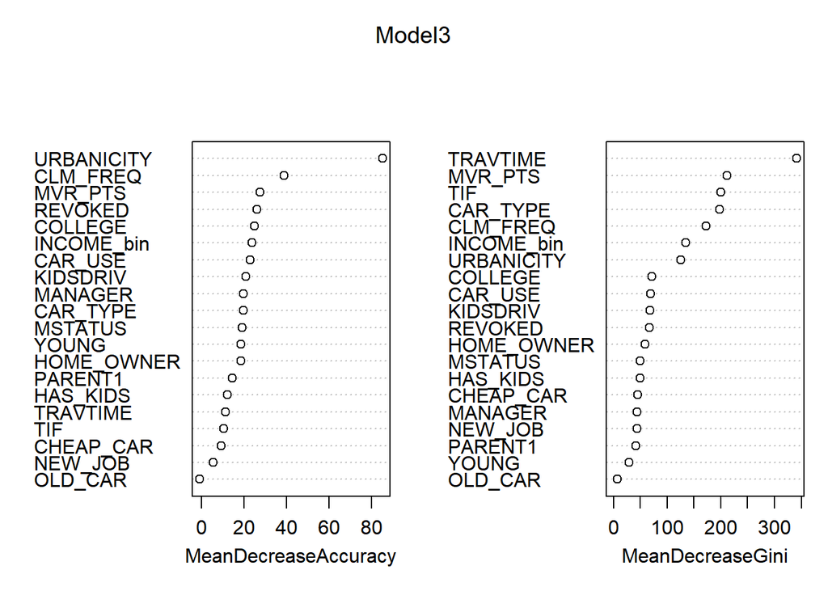

```r
varImpPlot(Model3)
```

```r
#Boosting
set.seed(4)

Model4 <- train(TARGET_FLAG ~ YOUNG + CHEAP_CAR + TRAVTIME + KIDSDRIV + URBANICITY + HAS_KIDS +
                  CLM_FREQ + REVOKED + MVR_PTS + OLD_CAR + TIF + COLLEGE + MSTATUS + PARENT1 +
                  CAR_USE + CAR_TYPE + NEW_JOB + MANAGER + INCOME_bin + HOME_OWNER,
                  method = "gbm", verbose = FALSE, data = data[train.set,])
Model4
```

```
## Stochastic Gradient Boosting
##
## 6528 samples
##   20 predictor
##    2 classes: '0', '1'
##
## No pre-processing
## Resampling: Bootstrapped (25 reps)
## Summary of sample sizes: 6528, 6528, 6528, 6528, 6528, 6528, ...
## Resampling results across tuning parameters:
##
##   interaction.depth  n.trees  Accuracy   Kappa
##   1                   50      0.7540921  0.1344697
##   1                  100      0.7707116  0.2517518
##   1                  150      0.7757918  0.3002399
##   2                   50      0.7698714  0.2463542
##   2                  100      0.7800194  0.3293361
##   2                  150      0.7826821  0.3557552
##   3                   50      0.7748579  0.2882333
##   3                  100      0.7835377  0.3566582
##   3                  150      0.7840151  0.3690374
##
## Tuning parameter 'shrinkage' was held constant at a value of 0.1
##
## Tuning parameter 'n.minobsinnode' was held constant at a value of 10
## Accuracy was used to select the optimal model using the largest value.
## The final values used for the model were n.trees = 150, interaction.depth =
##  3, shrinkage = 0.1 and n.minobsinnode = 10.
```

```r
Model4.pred <- predict(Model4, data[test.set,], type = "raw")

confusionMatrix(Model4.pred, data$TARGET_FLAG[test.set], positive = "1")
```

```
## Confusion Matrix and Statistics
##
##           Reference
## Prediction    0    1
##          0 1134  256
##          1   73  170
##
##                Accuracy : 0.7985
##                  95% CI : (0.7782, 0.8177)
##     No Information Rate : 0.7391
##     P-Value [Acc > NIR] : 1.17e-08
##
##                   Kappa : 0.3932
##
##  Mcnemar's Test P-Value : < 2.2e-16
##
##             Sensitivity : 0.3991
##             Specificity : 0.9395
##          Pos Pred Value : 0.6996
##          Neg Pred Value : 0.8158
##              Prevalence : 0.2609
##          Detection Rate : 0.1041
##    Detection Prevalence : 0.1488
##       Balanced Accuracy : 0.6693
##
##        'Positive' Class : 1
##
```

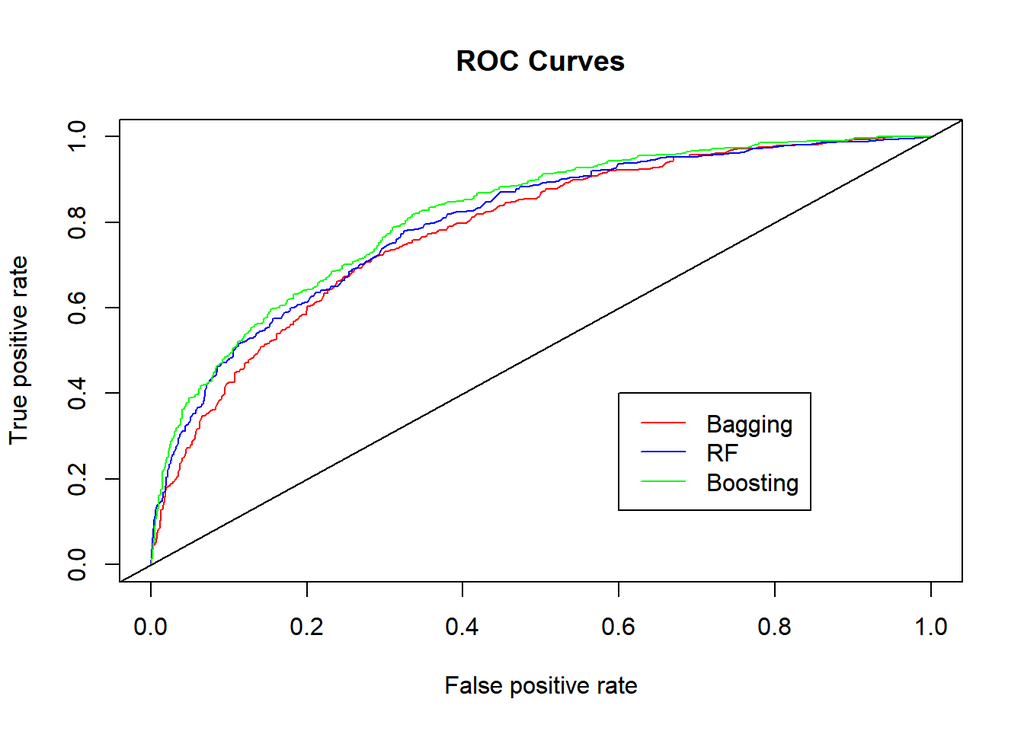

```r
#Compare ROC Curves
Model2.ROC <- predict(Model2, type = "prob", newdata = data[test.set,])
Model2.ROCpred <- prediction(Model2.ROC[,2], data$TARGET_FLAG[test.set])
Model2.perf <- performance(Model2.ROCpred, "tpr", "fpr")

Model3.ROC <- predict(Model3, type = "prob", newdata = data[test.set,])
Model3.ROCpred <- prediction(Model3.ROC[,2], data$TARGET_FLAG[test.set])
Model3.perf <- performance(Model3.ROCpred, "tpr", "fpr")

Model4.ROC <- predict(Model4, type = "prob", newdata = data[test.set,])
Model4.ROCpred <- prediction(Model4.ROC[,2], data$TARGET_FLAG[test.set])
Model4.perf <- performance(Model4.ROCpred, "tpr", "fpr")

plot(Model2.perf, col = "red", main = "ROC Curves")
plot(Model3.perf, col = "blue",add = TRUE)
plot(Model4.perf, col = "green", add = TRUE)
legend(0.6, 0.4, col = c("red", "blue", "green"), lty = 1, legend = c("Bagging", "RF", "Boosting"))

abline(a= 0, b = 1)
```

```r
auc.perf2 <- performance(Model2.ROCpred, measure = "auc")
auc.perf3 <- performance(Model3.ROCpred, measure = "auc")
auc.perf4 <- performance(Model4.ROCpred, measure = "auc")

auc.perf2@y.values
```

```
## [[1]]
## [1] 0.7834133
```

```r
auc.perf3@y.values
```

```
## [[1]]
## [1] 0.8003479
```

```r
auc.perf4@y.values
```

```
## [[1]]
## [1] 0.8165718
```

## Model Selection

Four different methods were used to model the insurance data. The first method was a classification decision tree. This method predicts an outcome based on a series of splits that are determined by the different predictor variables. This method had 73% total accuracy, however it significantly underperformed in identifying clients who would file a claim. The second method was bagging. This uses decision trees like the first method, however it uses random sample sets to generate many different trees, which decreases the variance of the final output. The third method was a random forest. This method is very similar to bagging, except that a random subset of predictor variables are used to split each of the trees. This helps to decorrelate the trees. The final method used was a gradient boosting machine. This method builds multiple trees, except that each tree built attempts to correct the errors of the previous tree. Bagging, random forest, and gradient boosting all produced models with similar performance. The areas under the curve for their receiver operating characteristics curves were within 0.03 of eachother and their accuracies were within 0.03 of eachother. Both of the previously stated metrics are measured on a scale between zero and one. Model Two, the bagging method, was chosen because it had the highest rate of detecting claims, which is the ultimate goal of the insurance agency.